# Inférence d’un réseau entre stations météorologiques

Université de Bordeaux - M2 MAS - UE : Statistique en grande dimension

Année 2025-2026

**Nom : Rita** **Prénom : Mathis**

**Nom : de Maillard**  
**Prénom : Amélie**

Dans ce projet, il est proposé d’analyser un jeu de données issues de mesures prises en différentes stations météorologiques durant l’année 2016 dans le nord-ouest de la France. Le but de projet est l’inférence d’un graphe de corrélation partielle entre certaines variables météorologiques à l’aide des outils d’estimation en grande dimension dans des modèles graphiques.

Le jeu de données peut être téléchargé via ce lien :

https://filesender.renater.fr/?s=download&token=db59f713-a603-42fc-9b91-a72b833461b9

#### Données disponibles sur les stations de mesure

Sur l’année 2016, on observe des données d’apprentissage sur $p = 262$ stations météorologiques dont on dispose des coordonnées spatiales (latitude et longitude).

Pour chaque station $1 \leq j \leq p$, on dispose des mesures suivantes :

**Variables explicatives** : mesure de $q = 6$ variables $X_{ijt} = (X_{ijt}^{(k)})_{1 \leq k \leq q} \in \mathbb{R}^{q}$ pour la station $j$, le jour $i$ et l’heure $t \in \{0,\ldots,23 \}$ (variable ordonnée). Les mesures sont

- ‘ff’ : *Vitesse du vent (en m/s)*
- ‘t’ : *Température (en Kelvin)*
- ‘td’ : *Point de rosée (en Kelvin)*
- ‘hu’ : *Humidité (en pourcentage)*
- ‘dd’ : *Direction du vent (en degrés)*
- ‘precip’ : *Cumul de pluie sur une heure (en ml)*

**Travail à effectuer par groupe.**

- pour une ou plusieurs des 6 variables ci-dessus, vous devez créer une matrice $X$ de taille $n \times p$ avec $n=366$ (nombre de jours en 2016) dont chaque entrée $X_{ij}$ est une statistique (par exemple la moyenne sur 24 heures) issue des observations journalière d’une de ces variables le jour $i$ et pour la station $j$. On veillera à retirer une tendance annuelle (moyenne journalière sur l’ensemble des stations) liée à la mesure choisie pour construire les $X_{ij}$.
- inférer à partir de la matrice $X$, un graphe de corrélation partielle entre les stations et le représenter sur une carte

# Lecture des données

On présente ci-dessous un exemple de lecture de ces données, et la représentation géographique des positions des stations météorologiques avec des liens qui correpondent aux $k=2$ plus proches voisins de chaque station.

Dans un premier temps, vous pourrez chercher à construire un graphe basé sur la notion usuelle de corrélation, en indiquant par des arêtes entre deux stations les corrélations non-nulles (estimées à l’aide d’un test d’hypothèses multiples).

```r
# Lecture des données
X_2016 = read.csv("X_2016_final.csv")
dim(X_2016)
```

```
## [1] 92209   146
```

```r
names(X_2016)
```

```
##   [1] "ff_0"       "ff_1"       "ff_10"      "ff_11"      "ff_12"
##   [6] "ff_13"      "ff_14"      "ff_15"      "ff_16"      "ff_17"
##  [11] "ff_18"      "ff_19"      "ff_2"       "ff_20"      "ff_21"
##  [16] "ff_22"      "ff_23"      "ff_3"       "ff_4"       "ff_5"
##  [21] "ff_6"       "ff_7"       "ff_8"       "ff_9"       "t_0"
##  [26] "t_1"        "t_10"       "t_11"       "t_12"       "t_13"
##  [31] "t_14"       "t_15"       "t_16"       "t_17"       "t_18"
##  [36] "t_19"       "t_2"        "t_20"       "t_21"       "t_22"
##  [41] "t_23"       "t_3"        "t_4"        "t_5"        "t_6"
##  [46] "t_7"        "t_8"        "t_9"        "td_0"       "td_1"
##  [51] "td_10"      "td_11"      "td_12"      "td_13"      "td_14"
##  [56] "td_15"      "td_16"      "td_17"      "td_18"      "td_19"
##  [61] "td_2"       "td_20"      "td_21"      "td_22"      "td_23"
##  [66] "td_3"       "td_4"       "td_5"       "td_6"       "td_7"
##  [71] "td_8"       "td_9"       "hu_0"       "hu_1"       "hu_10"
##  [76] "hu_11"      "hu_12"      "hu_13"      "hu_14"      "hu_15"
##  [81] "hu_16"      "hu_17"      "hu_18"      "hu_19"      "hu_2"
##  [86] "hu_20"      "hu_21"      "hu_22"      "hu_23"      "hu_3"
##  [91] "hu_4"       "hu_5"       "hu_6"       "hu_7"       "hu_8"
##  [96] "hu_9"       "dd_0"       "dd_1"       "dd_10"      "dd_11"
## [101] "dd_12"      "dd_13"      "dd_14"      "dd_15"      "dd_16"
## [106] "dd_17"      "dd_18"      "dd_19"      "dd_2"       "dd_20"
## [111] "dd_21"      "dd_22"      "dd_23"      "dd_3"       "dd_4"
## [116] "dd_5"       "dd_6"       "dd_7"       "dd_8"       "dd_9"
## [121] "precip_0"   "precip_1"   "precip_10"  "precip_11"  "precip_12"
## [126] "precip_13"  "precip_14"  "precip_15"  "precip_16"  "precip_17"
## [131] "precip_18"  "precip_19"  "precip_2"   "precip_20"  "precip_21"
## [136] "precip_22"  "precip_23"  "precip_3"   "precip_4"   "precip_5"
## [141] "precip_6"   "precip_7"   "precip_8"   "precip_9"   "number_sta"
## [146] "day"
```

```r
# Nombre de stations avec observations en 2016
names_stations = unique(X_2016$number_sta)
length(names_stations)
```

```
## [1] 262
```

```r
# Nombre de jours
length(unique(X_2016$day))
```

```
## [1] 366
```

```r
# Importation des coordonnées géographiques des stations de mesures
library(readr)
stations_coordinates_all <- read_csv("stations_coordinates.csv")
names(stations_coordinates_all)
```

```
## [1] "number_sta" "lat"        "lon"        "height_sta"
```

```r
# Intersection avec le nombre de stations avec observations en 2016
length(stations_coordinates_all$number_sta)
```

```
## [1] 325
```

```r
pos = is.element(stations_coordinates_all$number_sta, names_stations)
sum(pos)
```

```
## [1] 262
```

```r
stations_coordinates = stations_coordinates_all[pos,]
dim(stations_coordinates)
```

```
## [1] 262   4
```

```r
library(leaflet)
library(igraph)

# Recherche de kNN
library(FastKNN)
dist_mat <- as.matrix(dist(stations_coordinates[,c(2,3)]))
k <- 2 # Nbre de plus proches voisins
nrst <- lapply(1:nrow(dist_mat), function(i) k.nearest.neighbors(i, dist_mat, k = k))
# print(nrst)

# Construction d'une matrice adjacence A symmétrique
A <- matrix(0, nrow = dim(dist_mat), ncol=dim(dist_mat))
for(i in 1:length(nrst)) for(j in nrst[[i]]) A[i,j] = 1
for(i in 1:length(nrst)) for(j in nrst[[i]]) A[j,i] = 1

# Obtention du data.frame d'information sur les somments et les arretes du graphe
rownames(A) <- colnames(A) <- as.matrix(stations_coordinates[,1])
g <- graph_from_adjacency_matrix(t(A), weighted=TRUE) %>%
  set_vertex_attr("longitude", value = as.matrix(stations_coordinates["lon"])) %>%
  set_vertex_attr("latitude", value = as.matrix(stations_coordinates["lat"]))
gg <- get.data.frame(g, "both")

# Collection de tous les coornodonees à tracer
vert <- gg$vertices
rownames(vert) <- vert$name

# Importation de la collection des coornodonees dans le systeme de SpatialLines
library(sp)
coordinates(vert) <- ~longitude+latitude

# Identifier les droites à tracer et les transferer en classe SpatialLines
line <- function(i){
  return(as(rbind(vert[vert$name == gg$edges[i, "from"], ],
                    vert[vert$name == gg$edges[i, "to"], ]), "SpatialLines")) # arrets
}

edges <- lapply(1:nrow(gg$edges), line)
for (i in seq_along(edges)) {
  edges[[i]] <- spChFIDs(edges[[i]], as.character(i))
}
edges <- do.call(rbind, edges)

noloop <- gg$edges$from != gg$edges$to

# Visualisation
N <- dim(A)[1]
leaflet(vert[1:N,]) %>% addTiles() %>%
  addCircleMarkers(data = vert[1:N,])%>%
  addPolylines(data = edges[1:nrow(gg$edges),radius=0.05],
               weight = 5*gg$edges$weight)
```

[interactive chart not shown]

```r
# Construction de la matrice des données
# Nombre de stations avec observations en 2016
names_stations = unique(X_2016$number_sta)
p = length(names_stations)
print(p)

# Nombre de jours
n = length(unique(X_2016$day))
print(n)

liste_jours = sort(unique(X_2016$day))
head(X_2016[,c("number_sta","day")])

# Choix d'une variable
k = 2 # Température (en Kelvin)
nb_heures = 24

# Matrice des données pour cette variable
X = matrix(0,n,p)

for (i in 1:n) {
  # print(i)
  for (j in 1:p) {
    pos = (X_2016[,"day"] == liste_jours[i]) & (X_2016[,"number_sta"] == names_stations[j])
    X[i,j] = mean(as.numeric(X_2016[pos,1+(nb_heures*(k-1)):(nb_heures*k-1)]),na.rm=TRUE)
  }
}

# Visualisation
matplot(1:n,X[,1:10]-273.15,type="l")

# Visulisation
matplot(1:n,X[,100:110]-273.15,type="l")
```

[output not shown]

```r
library(igraph)
library(sp)
library(leaflet)
library(huge)
library(corrplot)
```

Tout d’abord, nous préparons les données et nous faisons les vérifications.

```r
# 0) Lecture des données

X_2016 <- read.csv("X_2016_final.csv")

# Stations et jours
names_stations <- sort(unique(X_2016$number_sta))
liste_jours    <- sort(unique(X_2016$day))

p <- length(names_stations)
n <- length(liste_jours)

cat("Nombre de stations p =", p, "\n")
```

```
## Nombre de stations p = 262
```

```r
cat("Nombre de jours n =", n, "\n")
```

```
## Nombre de jours n = 366
```

```r
stopifnot(n == 366)  # 2016 est bissextile
```

On dispose de mesures horaires en 2016 pour $p = 262$ stations météorologiques et $n = 366$ jours.

# Analyse descriptive des variables météorologiques

Avant toute inférence de réseau, il est essentiel d’explorer la distribution et la structure des variables météorologiques considérées. Cette section est consacrée à la construction des matrices journalières pour les six variables disponibles, à l’étude de leur distribution, puis au nettoyage des données par retrait d’une tendance journalière commune. Ces étapes permettent de mieux comprendre la nature des données et de préparer des matrices adaptées à l’analyse de dépendances spatiales.

```r
# FONCTION: Construction de X (jours x stations) pour une variable

build_X_variable <- function(X_2016, var_name, names_stations, liste_jours,
                             stat_fun = mean, na.rm_stat = TRUE) {
  hour_cols <- paste0(var_name, "_", 0:23)

  if (!all(hour_cols %in% names(X_2016))) {
    missing_cols <- hour_cols[!(hour_cols %in% names(X_2016))]
    stop("Colonnes manquantes pour ", var_name, " : ", paste(missing_cols, collapse = ", "))
  }

  n <- length(liste_jours)
  p <- length(names_stations)

  X <- matrix(NA_real_, nrow = n, ncol = p)
  rownames(X) <- liste_jours
  colnames(X) <- names_stations

  # verif doublons (jour, station)
  tab_counts <- table(X_2016$day, X_2016$number_sta)
  dup_pairs <- sum(tab_counts > 1)
  cat("[", var_name, "] Couples (jour, station) avec doublons :", dup_pairs, "\n")

  for (i in seq_len(n)) {
    day_i <- liste_jours[i]
    data_day <- X_2016[X_2016$day == day_i, ]

    for (j in seq_len(p)) {
      sta_j <- names_stations[j]
      data_ij <- data_day[data_day$number_sta == sta_j, hour_cols]

      if (nrow(data_ij) == 1) {
        X[i, j] <- stat_fun(as.numeric(data_ij[1, ]), na.rm = na.rm_stat)
      } else {
        X[i, j] <- NA_real_
      }
    }
  }

  return(X)
}
```

```r
# Construction des matrices X pour chaque variable

vars <- c("ff", "t", "td", "hu", "dd", "precip")

X_list <- list()

for (v in vars) {
  cat("Construction de X pour la variable :", v, "\n")
  X_list[[v]] <- build_X_variable(
    X_2016 = X_2016,
    var_name = v,
    names_stations = names_stations,
    liste_jours = liste_jours,
    stat_fun = mean
  )
  cat("  NA dans X :", sum(is.na(X_list[[v]])), "\n\n")
}
```

```
## Construction de X pour la variable : ff
## [ ff ] Couples (jour, station) avec doublons : 0
##   NA dans X : 40683
##
## Construction de X pour la variable : t
## [ t ] Couples (jour, station) avec doublons : 0
##   NA dans X : 8339
##
## Construction de X pour la variable : td
## [ td ] Couples (jour, station) avec doublons : 0
##   NA dans X : 33963
##
## Construction de X pour la variable : hu
## [ hu ] Couples (jour, station) avec doublons : 0
##   NA dans X : 33903
##
## Construction de X pour la variable : dd
## [ dd ] Couples (jour, station) avec doublons : 0
##   NA dans X : 40731
##
## Construction de X pour la variable : precip
## [ precip ] Couples (jour, station) avec doublons : 0
##   NA dans X : 9385
```

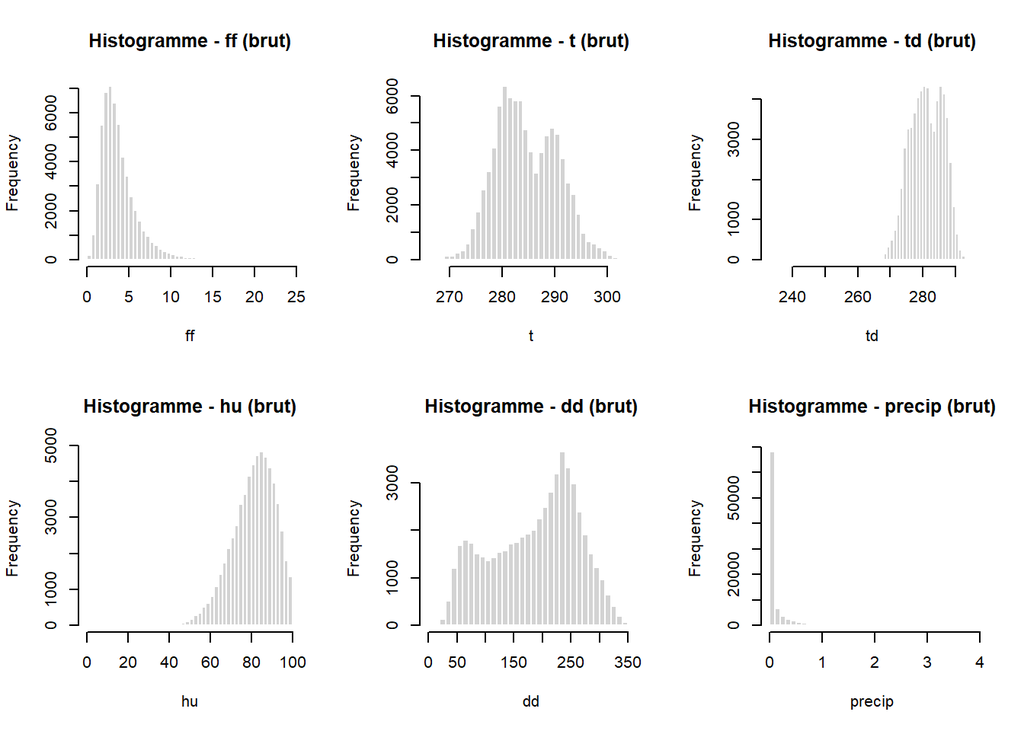

```r
# Histogrammes des X bruts

par(mfrow = c(2, 3))
for (v in vars) {
  hist(
    as.vector(X_list[[v]]),
    breaks = 50,
    main = paste("Histogramme -", v, "(brut)"),
    xlab = v,
    col = "lightgray",
    border = "white"
  )
}
```

```r
par(mfrow = c(1, 1))
```

Les histogrammes mettent en évidence des distributions très différentes selon la variable considérée. La température, l’humidité et le point de rosée présentent des distributions relativement continues, tandis que les précipitations sont fortement asymétriques avec une masse importante de valeurs nulles. La vitesse du vent présente aussi des valeurs assez faibles. La direction du vent montrent une variabilité plus marquée, reflétant le caractère instationnaire de ce phénomène.

Les variables météorologiques présentent une variation journalière commune à l’ensemble des stations, liée au cycle annuel. Pour chaque variable k, on définit :
$$m_i^{(k)} = \frac{1}{p}\sum_{j=1}^{p} X_{ij}^{(k)}, \quad \tilde{X}_{ij}
= X_{ij}^{(k)} - m_{i}^{(k)}$$
On retire cette tendance afin de se concentrer sur les variations spatiales entre stations.

```r
# FONCTION: retire trend + garde stations complètes

detrend_and_clean <- function(X) {
  daily_mean <- rowMeans(X, na.rm = TRUE)
  X_detrend <- sweep(X, 1, daily_mean, FUN = "-")

  keep_station <- colSums(is.na(X_detrend)) == 0
  X_clean <- X_detrend[, keep_station, drop = FALSE]

  list(
    X_detrend = X_detrend,
    keep_station = keep_station,
    X_clean = X_clean
  )
}

X_clean_list <- list()

for (v in vars) {
  cat("Nettoyage pour la variable :", v, "\n")
  res <- detrend_and_clean(X_list[[v]])
  X_clean_list[[v]] <- res$X_clean

  cat("  Dimensions après nettoyage :", dim(X_clean_list[[v]]), "\n")
  cat("  Stations supprimées :", sum(!res$keep_station), "\n\n")
}
```

```
## Nettoyage pour la variable : ff
##   Dimensions après nettoyage : 366 104
##   Stations supprimées : 158
##
## Nettoyage pour la variable : t
##   Dimensions après nettoyage : 366 166
##   Stations supprimées : 96
##
## Nettoyage pour la variable : td
##   Dimensions après nettoyage : 366 112
##   Stations supprimées : 150
##
## Nettoyage pour la variable : hu
##   Dimensions après nettoyage : 366 113
##   Stations supprimées : 149
##
## Nettoyage pour la variable : dd
##   Dimensions après nettoyage : 366 99
##   Stations supprimées : 163
##
## Nettoyage pour la variable : precip
##   Dimensions après nettoyage : 366 164
##   Stations supprimées : 98
```

On visualise quelques séries journalières pour chaque variable afin de vérifier que la tendance annuelle a bien été supprimée.

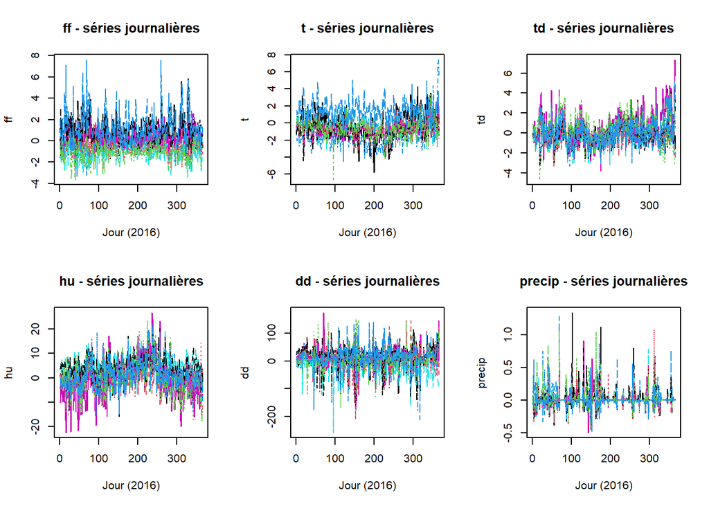

```r
# Séries journalières (tendance retirée)

par(mfrow = c(2, 3))
for (v in vars) {
  Xv <- X_clean_list[[v]]
  matplot(
    1:nrow(Xv),
    Xv[, 1:min(10, ncol(Xv))],
    type = "l",
    main = paste(v, "- séries journalières"),
    xlab = "Jour (2016)",
    ylab = v
  )
}
```

```r
par(mfrow = c(1, 1))
```

Après retrait de la tendance journalière, les séries sont centrées autour de zéro, ce qui confirme que la composante annuelle commune a été correctement supprimée. Hormis pour la précipitation, mais cela est normale car il ne pleut pas tous les jours. Les dynamiques résiduelles reflètent désormais principalement des variations locales et spatiales.

Enfin, on compare les distributions avant et après retrait de la tendance.

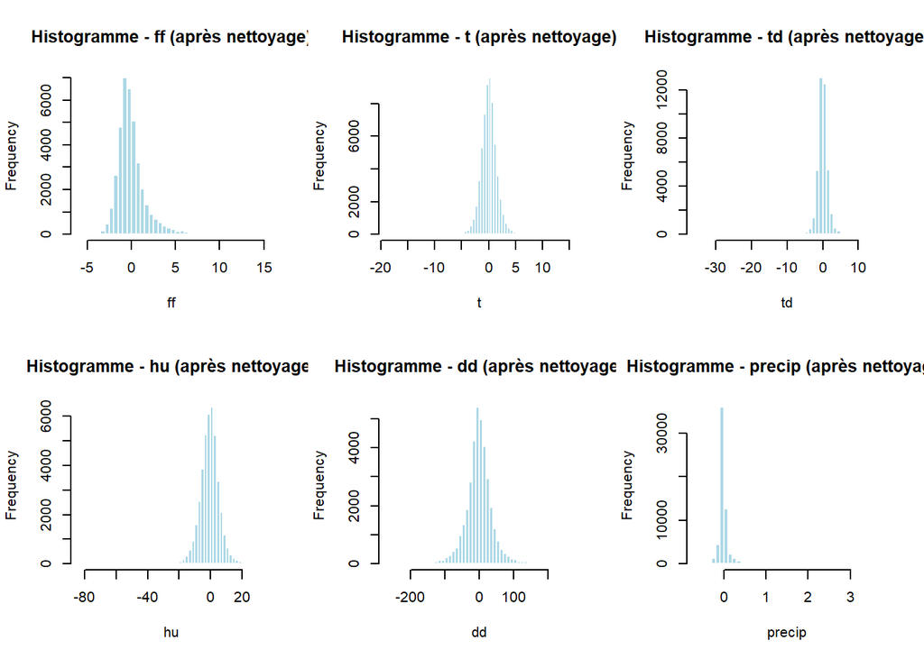

```r
# Histogrammes après nettoyage

par(mfrow = c(2, 3))
for (v in vars) {
  hist(
    as.vector(X_clean_list[[v]]),
    breaks = 50,
    main = paste("Histogramme -", v, "(après nettoyage)"),
    xlab = v,
    col = "lightblue",
    border = "white"
  )
}
```

```r
par(mfrow = c(1, 1))
```

Les histogrammes des variables après retrait de la tendance journalière sont recentrés autour de zéro. Cette transformation permet d’éliminer les effets saisonniers globaux tout en conservant la variabilité spatiale nécessaire à l’inférence de réseaux de dépendances entre stations.

Cette analyse descriptive met en évidence la diversité des distributions et des dynamiques temporelles des variables météorologiques étudiées. Le prétraitement effectué, agrégation journalière, suppression des stations incomplètes et retrait de la tendance journalière, fournit des matrices de données adaptées à l’analyse de dépendances spatiales. Les sections suivantes exploitent ces matrices nettoyées pour l’inférence de graphes de corrélation et de corrélation partielle entre stations.

Nous allons commencer par la variable de température. C’est une variable qui a une distribution assez symétrique et pour laquelle on a retiré relativement peu de stations à cause des na.

# Variable Température

## Construction de la matrice X et retrait de la tendance annuelle pour la variable température

Nous prenons donc la température t, et nous faisons le choix de la statistique journalière. Nous allons maintenant reprendrendre les étapes vu précédemment.

Dans notre fichier, les colonnes sont du type t_0, t_1,…, t_23. On va donc sélectionner dynamiquement ces colonnes avec un motif.

```r
# 1) choix variable température

var_name <- "t"              # "t" = température
stat_fun <- mean
na.rm_stat <- TRUE           # on ignore les NA pour la moyenne intra-journée
```

Puis, on construit la matrice journalière $X \in \mathbb{R}^{n \times p}$ telle que $n = 366$ et $p = 262$. Chaque entrée $X_{ij}$ correspond à une statistique journalière (ici une moyenne sur 24h) pour le jour $i$ et la station $j$.

Pour un jour $i$, une station $j$ et la variable $k$ (ici $k = t$), on note $x_{ijt}^{(k)}$ la mesure à l’heure $t \in \left\{0,...,23\right\}$. On définit alors :
$$X_{ij} = \frac{1}{24}\sum_{t=0}^{23}x_{ijt}^{(k)}$$

```r
# 2) Construction de X (jours x stations)

# Colonnes de la variable choisie
hour_cols <- paste0(var_name, "_", 0:23)

# Vérification
if(!all(hour_cols %in% names(X_2016))) {
  missing_cols <- hour_cols[!(hour_cols %in% names(X_2016))]
  stop("Colonnes manquantes pour ", var_name, " : ", paste(missing_cols, collapse=", "))
}

# Initialisation
X <- matrix(NA_real_, nrow = n, ncol = p)
rownames(X) <- liste_jours
colnames(X) <- names_stations

# Vérification des doublons (jour, station)

tab_counts <- table(X_2016$day, X_2016$number_sta)

# Couples (jour, station) avec plus d'une observation
dup_pairs <- sum(tab_counts > 1)

cat("Nombre de couples (jour, station) avec doublons :", dup_pairs, "\n")
```

```
## Nombre de couples (jour, station) avec doublons : 0
```

```r
# Distribution du nombre d'observations par couple
table(tab_counts)
```

```
## tab_counts
##     0     1
##  3683 92209
```

```r
# Boucle
for (i in seq_len(n)) {
  day_i <- liste_jours[i]
  data_day <- X_2016[X_2016$day == day_i, ]  # toutes stations pour ce jour

  for (j in seq_len(p)) {
    sta_j <- names_stations[j]
    data_ij <- data_day[data_day$number_sta == sta_j, hour_cols]

    # Si la station n'a pas de ligne ce jour-là, data_ij est vide => on laisse NA
    if (nrow(data_ij) == 1) {
      X[i, j] <- stat_fun(as.numeric(data_ij[1, ]), na.rm = na.rm_stat)
    } else {
      X[i, j] <- NA_real_
    }
  }
}

# Petit check
cat("NA dans X :", sum(is.na(X)), "\n")
```

```
## NA dans X : 8339
```

```r
# Complétude des stations

# Nombre de jours observés par station
nb_days_station <- colSums(!is.na(X))

summary(nb_days_station)
```

```
##    Min. 1st Qu.  Median    Mean 3rd Qu.    Max.
##     0.0   362.2   366.0   334.2   366.0   366.0
```

```r
# Stations parfaitement complètes
sum(nb_days_station == n)
```

```
## [1] 166
```

```r
# Stations presque complètes (ex : >= 360 jours)
sum(nb_days_station >= 360)
```

```
## [1] 207
```

Les stations présentent des niveaux de complétude hétérogènes. Afin de travailler sur des séries temporelles comparables et éviter l’introduction de valeurs manquantes dans l’estimation du réseau, nous ne conserverons par la suite que les stations disposant de mesures journalières complètes sur l’année. Ce filtrage permet d’assurer une estimation stable de la matrice de covariance.

Les variables météorologiques possède une forte saisonnalité commune à toutes les stations. Pour isoler davantage les dépendances spatiales (entre stations) indépendamment de la variation annuelle globale, on retire, comme vu précédemment, une tendance journalière définie comme la moyenne sur toutes les stations :
$$m_i = \frac{1}{p}\sum_{j=1}^p X_{ij}$$
On définit ensuite la matrice sans cette tendance comme étant $\tilde{X}_{ij} = X_{ij} - m_i$.

```r
# 3) Retrait de tendance annuelle (effet jour)

daily_mean <- rowMeans(X, na.rm = TRUE)   # moyenne sur stations, pour chaque jour
X_detrend  <- sweep(X, 1, daily_mean, FUN = "-")

# Vérification
check <- rowMeans(X_detrend, na.rm = TRUE)
summary(check) #environ 0
```

```
##       Min.    1st Qu.     Median       Mean    3rd Qu.       Max.
## -2.830e-14 -1.142e-14  1.170e-16  1.174e-15  1.470e-14  2.830e-14
```

Numériquement, on obtient des valeurs de l’ordre de $10^{-14}$ ainsi, le retrait de tendance est appliqué.

Après la construction de $\tilde{X}$, on choisi de ne conserver que les stations complètes, c’est-à-dire celles qui ne contiennent aucune valeur manquante sur l’année. On supprime toute station $j$ telle qu’il existe une jour $i$ avec $\tilde{X}_{ij} = \text{NA}$

```r
# 4) Suppression des stations avec NA

keep_station <- colSums(is.na(X_detrend)) == 0
cat("Stations supprimées :", sum(!keep_station), "\n")
```

```
## Stations supprimées : 96
```

```r
X_clean <- X_detrend[, keep_station, drop = FALSE]
p_clean <- ncol(X_clean)

cat("Nouvelle dimension de X :", nrow(X_clean), "x", p_clean, "\n")
```

```
## Nouvelle dimension de X : 366 x 166
```

On remarque que 96 stations on été supprimés, on obtient donc une matrice $X \in \mathbb{R}^{366 \times 166}$

On fait la visualisation pour voir si la tendance annuelle a bien été retirée.

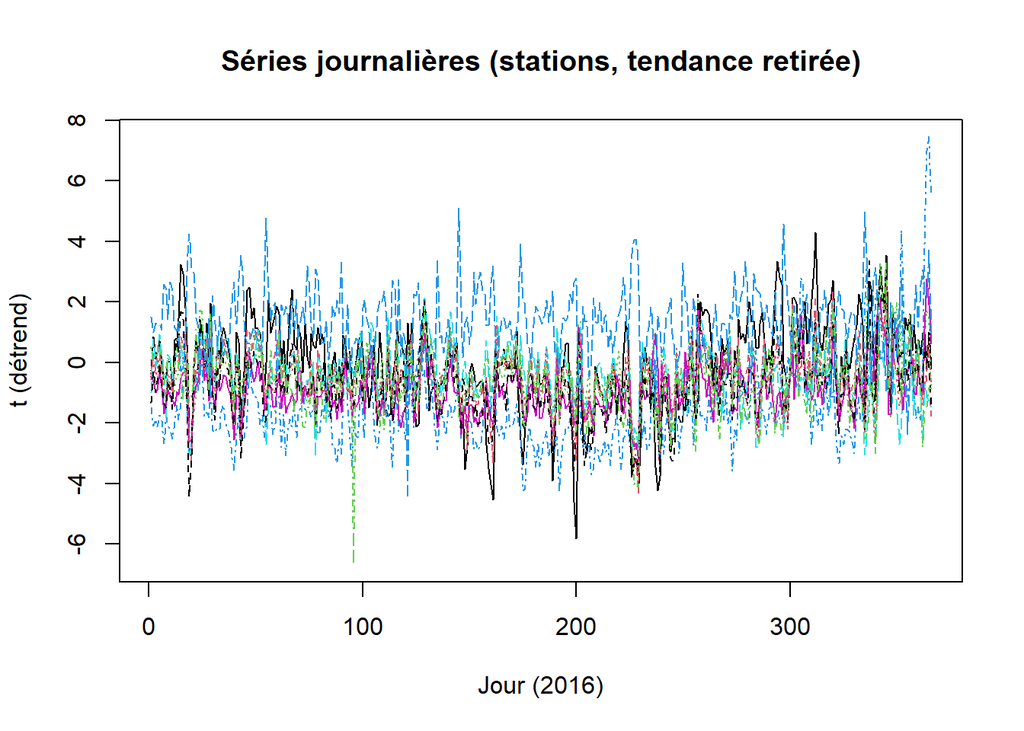

```r
# 5) Plots

# Exemple : 10 stations
matplot(1:nrow(X_clean), X_clean[, 1:min(10, p_clean)], type = "l",
        xlab = "Jour (2016)", ylab = paste0(var_name, " (détrend)"),
        main = "Séries journalières (stations, tendance retirée)")
```

## Analyse exploratoire par corrélation usuelle

La corrélation usuelle entre deux stations mesure leur dépendance marginale, sans tenir compte de l’influence des autres stations. Elle peut donc induire des liens indirects, notamment dus à la proximité géographique ou à des effets communs non observés. Cette analyse est utilisée ici à des fins exploratoires, avant l’inférence d’un réseau de dépendances conditionnelles via les corrélations partielles. Cette approche ne permet pas d’identifier des relations conditionnelles directes.

```r
# 1.1) Corrélations simples

# Les colonnes = stations
Cor <- cor(X_clean)

summary(as.vector(Cor[upper.tri(Cor)]))
```

```
##      Min.   1st Qu.    Median      Mean   3rd Qu.      Max.
## -0.843912 -0.409697 -0.027321  0.008164  0.408631  0.995396
```

La distribution des corrélations simples entre stations présente une médiane proche de zéro et une moyenne quasi nulle, ce qui indique l’absence de dépendance linéaire dominante globale entre les séries journalières après retrait de la tendance annuelle. Toutefois, la présence de corrélations très fortes, positives comme négatives (max $\approx 0.99$ et min $\approx -0.85$), suggère l’existence de relations locales marquées entre certaines stations, possiblement liées à la proximité géographique ou à des conditions météorologiques communes.

Tests d’hypothèses multiples : $H_0 : p_{ij} = 0$

```r
# 1.2) Tests multiples sur les corrélations

p_clean <- ncol(X_clean)
n <- nrow(X_clean)

# Statistique de test
t_stat <- Cor * sqrt((n - 2) / (1 - Cor^2))
pval <- 2 * pt(-abs(t_stat), df = n - 2)

# Correction de Benjamini-Hochberg
pval_vec <- pval[upper.tri(pval)]
pval_adj <- p.adjust(pval_vec, method = "BH")

# Seuil
alpha <- 0.05

# Matrice d'adjacence
Adj_cor <- matrix(FALSE, p_clean, p_clean)
Adj_cor[upper.tri(Adj_cor)] <- pval_adj < alpha
Adj_cor <- Adj_cor | t(Adj_cor)
diag(Adj_cor) <- FALSE

sum(Adj_cor) / 2
```

```
## [1] 11979
```

Nous avons un nombre d’arêtes de 11979, donc 11979 corrélations significativement différentes de 0.

```r
# 1.3) Graphe de corrélation simple

g_cor <- graph_from_adjacency_matrix(
  Adj_cor,
  mode = "undirected",
  diag = FALSE
)

g_cor
```

```
## IGRAPH 66f6031 U--- 166 11979 --
## + edges from 66f6031:
##  [1] 1--  2 1--  3 1--  4 1--  5 1--  6 1--  7 1--  8 1--  9 1-- 10 1-- 11
## [11] 1-- 12 1-- 13 1-- 14 1-- 15 1-- 16 1-- 17 1-- 18 1-- 19 1-- 20 1-- 23
## [21] 1-- 24 1-- 25 1-- 26 1-- 27 1-- 28 1-- 29 1-- 30 1-- 31 1-- 32 1-- 33
## [31] 1-- 34 1-- 35 1-- 36 1-- 37 1-- 38 1-- 39 1-- 40 1-- 41 1-- 42 1-- 45
## [41] 1-- 46 1-- 48 1-- 49 1-- 50 1-- 51 1-- 52 1-- 53 1-- 54 1-- 55 1-- 56
## [51] 1-- 57 1-- 58 1-- 59 1-- 60 1-- 61 1-- 62 1-- 63 1-- 64 1-- 65 1-- 66
## [61] 1-- 67 1-- 68 1-- 69 1-- 70 1-- 71 1-- 72 1-- 73 1-- 74 1-- 75 1-- 76
## [71] 1-- 77 1-- 78 1-- 79 1-- 80 1-- 82 1-- 83 1-- 85 1-- 86 1-- 87 1-- 88
## [81] 1-- 89 1-- 90 1-- 91 1-- 92 1-- 93 1-- 94 1-- 95 1-- 96 1-- 98 1--100
## + ... omitted several edges
```

Le graphe obtenu comporte 11 979 arêtes pour 166 stations, soit un graphe extrêmement dense. De nombreuses stations apparaissent connectées à une grande partie du réseau, rendant la structure difficilement interprétable. Cette densité élevée est caractéristique des graphes basés sur des corrélations marginales, qui ne distinguent pas les dépendances directes des dépendances indirectes induites par d’autres stations.

Cette analyse exploratoire met en évidence les limites de la corrélation simple pour l’inférence d’un réseau de dépendances entre stations.

Afin d’identifier des relations conditionnelles directes et d’obtenir un graphe plus parcimonieux et interprétable, nous considérons dans la section suivante l’estimation de corrélations partielles via un modèle graphique gaussien.

Visualisation du graphe de corrélation simple sur la carte :

```r
# Coordonnées des stations conservées


stations_clean <- stations_coordinates[
  stations_coordinates$number_sta %in% colnames(X_clean),
]

# Vérification de l'ordre
stations_clean <- stations_clean[
  match(colnames(X_clean), stations_clean$number_sta),
]

stopifnot(all(stations_clean$number_sta == colnames(X_clean)))

# Graphe de corrélation simple (spatial)
g_cor <- graph_from_adjacency_matrix(
  Adj_cor,
  mode = "undirected",
  diag = FALSE
)

# Noms des sommets
V(g_cor)$name <- colnames(X_clean)

# Ajout des coordonnées aux sommets
V(g_cor)$lon <- stations_clean$lon
V(g_cor)$lat <- stations_clean$lat

# Sommets
vert <- data.frame(
  id  = V(g_cor)$name,
  lon = V(g_cor)$lon,
  lat = V(g_cor)$lat
)

coordinates(vert) <- ~lon+lat

# Arêtes
edges_df <- as_data_frame(g_cor, what = "edges")

line_fun <- function(i) {
  as(
    rbind(
      vert[vert$id == edges_df$from[i], ],
      vert[vert$id == edges_df$to[i], ]
    ),
    "SpatialLines"
  )
}

edges <- lapply(seq_len(nrow(edges_df)), line_fun)
edges <- lapply(seq_along(edges), function(i) spChFIDs(edges[[i]], as.character(i)))
edges <- do.call(rbind, edges)

# Visualisation
leaflet(vert) %>%
  addTiles() %>%
  addCircleMarkers(radius = 3, opacity = 0.8) %>%
  addPolylines(
    data = edges,
    color = "red",
    weight = 1,
    opacity = 0.3
  )
```

[interactive chart not shown]

La visualisation spatiale du graphe de corrélation simple met en évidence un réseau extrêmement dense, où la majorité des stations sont connectées entre elles. Cette représentation confirme visuellement que la corrélation marginale ne permet pas d’isoler des relations directes entre stations, motivant le recours à des méthodes basées sur les corrélations partielles.

## Inférence d’un graphe de corrélation partielle

Contrairement à la corrélation simple, la corrélation partielle mesure la dépendance linéaire entre deux stations conditionnellement à l’ensemble des autres stations. Dans le cadre d’un modèle graphique gaussien, les dépendances conditionnelles sont codées par la matrice de précision $K = \Sigma^{-1}$, dont les coefficients nuls correspondent à des indépendances conditionnelles. Le graphe sous-jacent est alors défini par le support de $K$.

On commence par préparer les données en faisant une standardisation pour pouvoir comparer chacune des variables entre elles.

Avant de calculer une matrice de covariance et de l’inverser, on standardise les variables (stations) : chaque station est centrée-réduite. Cela permet de travailler sur une échelle comparable d’une station à l’autre.

```r
# 2.1) Corrélation partielle (classique) - préparation

X_std <- scale(X_clean, center = TRUE, scale = TRUE)
n <- nrow(X_std)
p <- ncol(X_std)
```

On estime d’abord la covariance empirique $\hat{\Sigma}$ à partir des données standardisées, puis on calcul son inverse $\hat{K} = \hat{\Sigma^{-1}}$

```r
# 2.2) Estimation classique de K = Sigma^{-1}

X_cov <- cov(X_std)

# Inversion
hat_K <- solve(X_cov)
```

Ici, $n > p$, donc $\hat{\Sigma}$ est inversible.

Puis, on calcul les corrélations conditionnelles telles que :
$$\rho_{ij} = \frac{-K_{ij}}{\sqrt{K_{ii}K_{jj}}}$$
Et on test, pour chaque paire $(i,j)$, l’hypothèse :
$$H_0 : \rho = 0 \quad \text{contre} \quad H_1 : \rho \neq 0$$
Avec une statistique de test de type Student telle que :
$$\hat{t_{ij}} = \sqrt{n-2-p}
\frac{\hat{\rho_{ij}}}{\sqrt{1-\hat{\rho_{ij}}^2}}$$
où $\hat{t_{ij}} \text{~} St(n-p-2)$ si $n>p+2$. On obtient ainsi une p-valeur pour chaque paire de stations.

```r
# 2.3) Corrélations partielles + p-values

D <- diag(hat_K)
rho_n <- -hat_K / sqrt( outer(D, D) )
diag(rho_n) <- 0

df <- n - p - 2
t_n <- rho_n / sqrt(1 - rho_n^2) * sqrt(df)

pvalue_n <- 2 * (1 - pt(abs(t_n), df = df))
diag(pvalue_n) <- 1  # pour éviter de sélectionner la diagonale
```

Comme on réalise un très grand nombre de tests, on applique une correction pour comparaisons multiples. Pour cela on utilise la correction de Benjamini–Hochberg (BH), qui contrôle le taux de fausses découvertes (FDR) au niveau $\alpha = 5%$. On définit ensuite la matrice d’adjacence $\hat{A}$ du graphe :

- $\hat{A_{ij}} = 1$ si la corrélation partielle est significativement non nulle,
- $\hat{A_{ij}} = 0$ sinon.

```r
# 2.4) Matrice d'adjacence (BH)

alpha <- 0.05

pval_vec <- pvalue_n[upper.tri(pvalue_n)]
pval_adj <- p.adjust(pval_vec, method = "BH")

Adj_pcor <- matrix(FALSE, p, p)
Adj_pcor[upper.tri(Adj_pcor)] <- pval_adj < alpha
Adj_pcor <- Adj_pcor | t(Adj_pcor)
diag(Adj_pcor) <- FALSE

sum(Adj_pcor) / 2
```

```
## [1] 260
```

```r
# Coordonnées des stations conservées


stations_clean <- stations_coordinates[
  stations_coordinates$number_sta %in% colnames(X_clean),
]

# Vérification de l'ordre
stations_clean <- stations_clean[
  match(colnames(X_clean), stations_clean$number_sta),
]

stopifnot(all(stations_clean$number_sta == colnames(X_clean)))

# 2.5) Graphe de corrélation simple (spatial)

g_pcor <- graph_from_adjacency_matrix(Adj_pcor, mode="undirected", diag=FALSE)
V(g_pcor)$name <- colnames(X_clean)

# coords : stations_clean déjà construit chez toi
V(g_pcor)$lon <- stations_clean$lon
V(g_pcor)$lat <- stations_clean$lat

# Sommets
vert <- data.frame(
  id  = V(g_pcor)$name,
  lon = V(g_pcor)$lon,
  lat = V(g_pcor)$lat
)

coordinates(vert) <- ~lon+lat

# Arêtes
edges_df <- as_data_frame(g_pcor, what = "edges")

line_fun <- function(i) {
  as(
    rbind(
      vert[vert$id == edges_df$from[i], ],
      vert[vert$id == edges_df$to[i], ]
    ),
    "SpatialLines"
  )
}

edges <- lapply(seq_len(nrow(edges_df)), line_fun)
edges <- lapply(seq_along(edges), function(i) spChFIDs(edges[[i]], as.character(i)))
edges <- do.call(rbind, edges)

# Visualisation
leaflet(vert) %>%
  addTiles() %>%
  addCircleMarkers(radius = 3, opacity = 0.8) %>%
  addPolylines(
    data = edges,
    color = "blue",
    weight = 1,
    opacity = 0.3
  )
```

[interactive chart not shown]

Le graphe obtenu comporte 260 arêtes pour 166 stations, soit un réseau très parcimonieux comparé au graphe de corrélation simple. Les liens restants correspondent à des dépendances conditionnelles directes entre stations, ce qui rend le réseau nettement plus interprétable spatialement.

## Inférence d’un graphe par Graphical Lasso

La corrélation partielle “classique” repose sur l’inversion de la covariance empirique. Même lorsque $n > p$ cette inversion peut être instable si la covariance est mal conditionnée. Le Graphical Lasso constitue alors une alternative pénalisée qui impose la parcimonie de $\hat{K}$ et améliore la robustesse de l’inférence du réseau.

```r
# 3.1) Graphical Lasso

S <- cov(X_std) # Matrice de covariance empirique

glasso_res <- huge(
  X_std,
  method = "glasso",
  nlambda = 40
)
```

[output not shown]

```r
names(glasso_res)
```

```
##  [1] "method"     "path"       "lambda"     "icov"       "df"
##  [6] "sparsity"   "loglik"     "cov.input"  "cov.output" "scr"
## [11] "data"
```

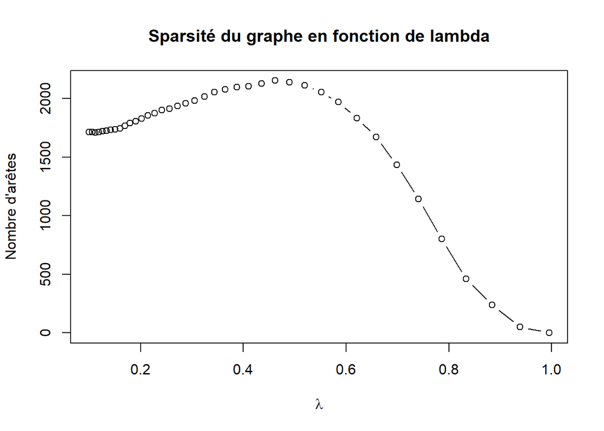

```r
p <- ncol(X_std)

nb_edges <- glasso_res$sparsity * ((p^2 - p) / 2)

plot(
  glasso_res$lambda,
  nb_edges,
  type = "b",
  xlab = expression(lambda),
  ylab = "Nombre d'arêtes",
  main = "Sparsité du graphe en fonction de lambda"
)
```

Il nous faut ensuite sélectionner une valeur de $\lambda$. L’objectif est de choisir le paramètre $\lambda$ de manière à obtenir un graphe parcimonieux tout en conservant une structure non triviale. Nous pouvons par exemple choisir arbitrairement une valeur de $\lambda$, mais il existe plusieurs méthodes qui permettent un choix “automatique”. Nous allons commencer par utiliser un critère d’information pénalisant la complexité du modèle. En particulier, nous considérons les critères AIC et BIC, calculés à partir de la log-vraisemblance associée aux estimateurs fournis par le Graphical Lasso.

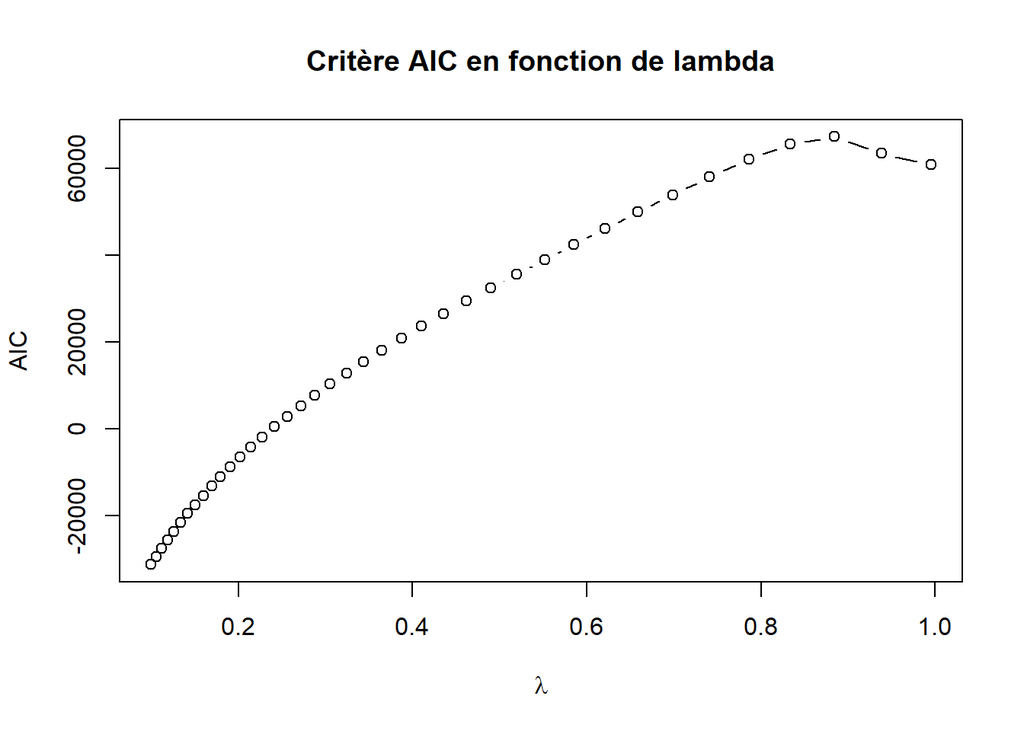

```r
# 3.2) Choix du lambda avec AIC/BIC
# Degrés de liberté (nombre de paramètres non nuls)
degree_glasso <- glasso_res$df

# Critère AIC
AIC_glasso <- -2 * glasso_res$loglik * (n / 2) + 2 * degree_glasso

# Critère BIC
BIC_glasso <- -2 * glasso_res$loglik * (n / 2) + log(n) * degree_glasso

# Visualisation
plot(glasso_res$lambda, AIC_glasso, type = "b",
     xlab = expression(lambda), ylab = "AIC",
     main = "Critère AIC en fonction de lambda")
```

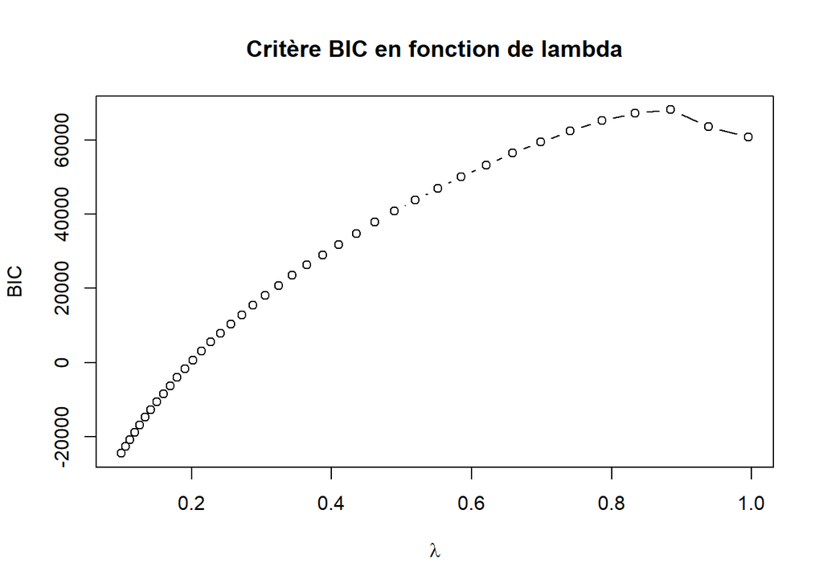

```r
plot(glasso_res$lambda, BIC_glasso, type = "b",
     xlab = expression(lambda), ylab = "BIC",
     main = "Critère BIC en fonction de lambda")
```

```r
# Valeurs sélectionnées
k_AIC <- which.min(AIC_glasso)
k_BIC <- which.min(BIC_glasso)
```

Le deux critères conduisent à des valeurs de $\lambda$ très faible, correspondant à des graphes très denses où la pénalisation est donc minime. Dans la suite, nous retenons la valeur sélectionnée par AIC (la même qu’avec le BIC, il s’agit de la plus petite des 40 valeurs de lambda).

```r
k <- k_AIC   # ou k_BIC
Theta_hat <- glasso_res$path[[k]]

Adj_glasso <- abs(Theta_hat) > 1e-4 #seuil
diag(Adj_glasso) <- 0
```

```r
lambda_avec_AIC <- glasso_res$lambda[k]
lambda_avec_AIC
```

```
## [1] 0.0995396
```

Notre valeur de lambda conservé est 0.0995396.

```r
g_glasso <- graph_from_adjacency_matrix(
  Adj_glasso,
  mode = "undirected",
  diag = FALSE
)

V(g_glasso)$lon <- stations_clean$lon
V(g_glasso)$lat <- stations_clean$lat
V(g_glasso)$name <- colnames(X_std)

vert <- data.frame(
  id  = V(g_glasso)$name,
  lon = V(g_glasso)$lon,
  lat = V(g_glasso)$lat
)

coordinates(vert) <- ~lon+lat

edges_df <- as_data_frame(g_glasso, what = "edges")

line_fun <- function(i) {
  as(
    rbind(
      vert[vert$id == edges_df$from[i], ],
      vert[vert$id == edges_df$to[i], ]
    ),
    "SpatialLines"
  )
}

edges <- lapply(seq_len(nrow(edges_df)), line_fun)
edges <- lapply(seq_along(edges), function(i)
  spChFIDs(edges[[i]], as.character(i))
)
edges <- do.call(rbind, edges)

leaflet(vert) %>%
  addTiles() %>%
  addCircleMarkers(
    radius = 3,
    color = "black",
    fillOpacity = 0.8
  ) %>%
  addPolylines(
    data = edges,
    color = "blue",
    weight = 1,
    opacity = 0.5
  )
```

[interactive chart not shown]

Nous pouvons constater que le graphe est très dense dû au fait que nous prenons un lambda très petit avec cette méthode. Afin d’essayer d’obtenir un graphe plus parcimonieux et interprétable nous allons maintenant choisir le lambda grâce à une validation croisée.

```r
# 3.3) Choix du lambda avec CV

glasso_res <- huge(X_std, method = "glasso", nlambda = 40)
```

[output not shown]

```r
cv_select <- huge.select(glasso_res, criterion = "cv")

# Sélection du lambda optimal (meilleur loglik)
k <- which.min(cv_select$loglik)
lambda_avec_cv <- glasso_res$lambda[k]
lambda_avec_cv
```

```
## [1] 0.8845326
```

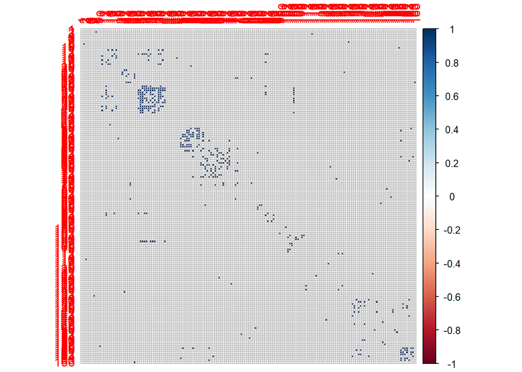

```r
Theta_hat <- cv_select$icov[[k]]

lambda_used <- cv_select$lambda[k]
#lambda_used


# Matrice d'adjacence
Adj_glasso <- abs(Theta_hat) > 1e-4
diag(Adj_glasso) <- 0

nb_edges <- sum(Adj_glasso) / 2
#nb_edges


# Visualisation matrice d'adjacence
corrplot(Adj_glasso)
```

```r
g_glasso <- graph_from_adjacency_matrix(
  Adj_glasso,
  mode = "undirected",
  diag = FALSE
)

V(g_glasso)$lon <- stations_clean$lon
V(g_glasso)$lat <- stations_clean$lat
V(g_glasso)$name <- colnames(X_std)

vert <- data.frame(
  id  = V(g_glasso)$name,
  lon = V(g_glasso)$lon,
  lat = V(g_glasso)$lat
)

coordinates(vert) <- ~lon+lat

edges_df <- as_data_frame(g_glasso, what = "edges")

line_fun <- function(i) {
  as(
    rbind(
      vert[vert$id == edges_df$from[i], ],
      vert[vert$id == edges_df$to[i], ]
    ),
    "SpatialLines"
  )
}

edges <- lapply(seq_len(nrow(edges_df)), line_fun)
edges <- lapply(seq_along(edges), function(i)
  spChFIDs(edges[[i]], as.character(i))
)
edges <- do.call(rbind, edges)

leaflet(vert) %>%
  addTiles() %>%
  addCircleMarkers(
    radius = 3,
    color = "black",
    fillOpacity = 0.8
  ) %>%
  addPolylines(
    data = edges,
    color = "blue",
    weight = 1,
    opacity = 0.5
  )
```

[interactive chart not shown]

```r
nb_edges
```

```
## [1] 234
```

Le graphe obtenu est nettement plus parcimonieux que celui obtenu avec AIC/BIC. Ici, le lambda conservé est 0.8845326. Il comporte désormais 234 arêtes, ce qui traduit une structure de dépendance plus claire et plus interprétable. La pénalisation est plus forte avec la validation croisée, ce qui force certains coefficients de la matrice de précision à s’annuler, supprimant ainsi les liens faibles ou redondants. Ici, cette méthode de sélection de $\lambda$ permet donc une meilleure compréhension du graphe.

On observe que les stations situées le long des côtes présentent davantage de connexions entre elles, tandis que les stations situées à l’intérieur des terres forment également un regroupement. Cela suggère que les dépendances conditionnelles captent des structures géographiques sous-jacentes, possiblement liées à des facteurs climatiques régionaux (influence maritime, relief,…).

# Variable direction du vent

Nous appliquons maintenant la même méthodologie à la variable dd correspondant à la direction du vent (en degrés). Comme précédemment, nous construisons une statistique journalière (moyenne sur 24h), retirons la tendance journalière commune, puis inférons un graphe de dépendance conditionnelle via le Graphical Lasso avec sélection de $\lambda$ par validation croisée.

```r
# Variable direction du vent
# Variable direction du vent
var_name <- "dd"

hour_cols <- paste0(var_name, "_", 0:23)

# IMPORTANT : redéfinir n correctement
liste_jours <- sort(unique(X_2016$day))
n <- length(liste_jours)

# p doit être le nombre total de stations
names_stations <- sort(unique(X_2016$number_sta))
p <- length(names_stations)

X_dd <- matrix(NA_real_, nrow = n, ncol = p)

rownames(X_dd) <- liste_jours
colnames(X_dd) <- names_stations


for (i in seq_len(n)) {
  day_i <- liste_jours[i]
  data_day <- X_2016[X_2016$day == day_i, ]

  for (j in seq_len(p)) {
    sta_j <- names_stations[j]
    data_ij <- data_day[data_day$number_sta == sta_j, hour_cols]

    if (nrow(data_ij) == 1) {
      X_dd[i, j] <- mean(as.numeric(data_ij[1, ]), na.rm = TRUE)
    }
  }
}

cat("NA dans X_dd :", sum(is.na(X_dd)), "\n")
```

```
## NA dans X_dd : 40731
```

```r
# Retrait tendance
daily_mean_dd <- rowMeans(X_dd, na.rm = TRUE)
X_dd_detrend  <- sweep(X_dd, 1, daily_mean_dd, FUN = "-")

# Stations complètes
keep_dd <- colSums(is.na(X_dd_detrend)) == 0
X_dd_clean <- X_dd_detrend[, keep_dd, drop = FALSE]

cat("Dimensions finales :", dim(X_dd_clean), "\n")
```

```
## Dimensions finales : 366 99
```

```r
X_dd_std <- scale(X_dd_clean)

glasso_dd <- huge(X_dd_std, method = "glasso", nlambda = 40)
```

[output not shown]

```r
cv_dd <- huge.select(glasso_dd, criterion = "cv")

k_dd <- which.min(cv_dd$loglik)

Theta_dd <- cv_dd$icov[[k_dd]]
lambda_dd <- cv_dd$lambda[k_dd]

cat("Lambda sélectionné :", lambda_dd, "\n")
```

```
## Lambda sélectionné : 0.6980494
```

```r
Adj_dd <- abs(Theta_dd) > 1e-4
diag(Adj_dd) <- 0

nb_edges_dd <- sum(Adj_dd) / 2
cat("Nombre d'arêtes :", nb_edges_dd, "\n")
```

```
## Nombre d'arêtes : 76
```

```r
stations_dd <- stations_coordinates[
  stations_coordinates$number_sta %in% colnames(X_dd_clean),
]

stations_dd <- stations_dd[
  match(colnames(X_dd_clean), stations_dd$number_sta),
]

g_dd <- graph_from_adjacency_matrix(
  Adj_dd,
  mode = "undirected",
  diag = FALSE
)

V(g_dd)$lon <- stations_dd$lon
V(g_dd)$lat <- stations_dd$lat
V(g_dd)$name <- colnames(X_dd_clean)

vert_dd <- data.frame(
  id  = V(g_dd)$name,
  lon = V(g_dd)$lon,
  lat = V(g_dd)$lat
)

edges_df_dd <- as_data_frame(g_dd, what = "edges")

edges_dd <- lapply(seq_len(nrow(edges_df_dd)), function(i) {
  coords <- as.matrix(
    vert_dd[vert_dd$id %in% c(edges_df_dd$from[i], edges_df_dd$to[i]), c("lon","lat")]
  )
  sp::Line(coords)
})

edges_dd <- lapply(seq_along(edges_dd),
                   function(i) sp::Lines(list(edges_dd[[i]]), ID=as.character(i)))

edges_dd_sp <- sp::SpatialLines(edges_dd)

coordinates(vert_dd) <- ~lon+lat

leaflet() %>%
  addTiles() %>%
  addCircleMarkers(
    data = vert_dd,
    radius = 3,
    color = "black",
    fillOpacity = 0.8
  ) %>%
  addPolylines(
    data = edges_dd_sp,
    color = "darkgreen",
    weight = 1,
    opacity = 0.5
  )
```

[interactive chart not shown]

Le graphe obtenu pour la direction du vent présente une structure légèrement différente de celle observée pour la température. Le nombre d’arêtes est de 76, ce qui traduit un niveau de dépendance conditionnelle assez faible.

On observe que les connexions apparaissent principalement dans des zones géographiques très spécifiques (pointe de la Bretagne, stations entre Tours et Poitiers, stations sous Nantes). En comparaison à la température, le réseau associé à la direction du vent met davantage en évidence des zones plus précises. Cela suggère que la direction du vent présente une influence géographique probablement d’autant plus marquée (ocean atlantique, relief, couloirs de vent).

Cependant, il convient de noter que la direction du vent est une variable angulaire définie sur $[0,360]$, ce qui peut limiter la pertinence d’une modélisation purement gaussienne. Malgré cette limite, l’approche par Graphical Lasso permet d’identifier des dépendances conditionnelles directes entre stations et des zones météorologiques spécifiques.

# Conclusion

Ce projet avait pour objectif d’étudier les dépendances entre stations météorologiques françaises à partir de données journalières en adoptant une approche de modèles graphiques gaussiens. Après avoir construit des indicateurs journaliers et retiré la tendance commune afin d’isoler les variations propres à chaque station, nous avons estimé la matrice de précision dans un cadre de grande dimension. L’utilisation du Graphical Lasso s’est révélée particulièrement adaptée car elle permet d’introduire une pénalisation favorisant la parcimonie et d’obtenir un réseau plus interprétable que l’estimation classique non pénalisée.

La sélection du paramètre de régularisation par validation croisée a permis de déterminer un compromis entre qualité d’ajustement et complexité du modèle. Contrairement à une estimation sans contrainte qui conduit à un graphe plus dense, la pénalisation L1 impose l’annulation de certains coefficients de la matrice de précision et met ainsi en évidence uniquement les dépendances conditionnelles directes entre stations. Le réseau obtenu pour la température révèle une structuration spatiale cohérente, avec des regroupements géographiques marqués et des connexions plus fréquentes entre stations proches ou appartenant à des zones climatiques similaires.

L’analyse de la direction du vent met également en évidence des structures régionales, suggérant l’influence de régimes atmosphériques communs et d’effets liés au relief ou à la proximité maritime. Bien que cette variable soit de nature angulaire et donc imparfaitement adaptée à une hypothèse gaussienne stricte, l’approche retenue permet néanmoins d’identifier des relations directes pertinentes entre stations et d’obtenir une représentation synthétique du réseau spatial.

Dans l’ensemble, ce travail illustre l’intérêt des modèles graphiques pénalisés pour l’étude de données spatiales de grande dimension. Cette méthodologie permet de dépasser l’analyse de corrélations simples et d’accéder à une structure de dépendance conditionnelle plus informative. Elle offre ainsi un outil puissant pour comprendre l’organisation spatiale des phénomènes climatiques et ouvre des perspectives pour des analyses plus fines intégrant d’autres variables météorologiques ou des extensions adaptées aux données non gaussiennes.